# Saglik Sigortasi Analizi

Fatma Zehra Cinar

# Soru 1

## (a)

```r
library(tidyverse)
load("sagliksig.rda")

# Veri setini eğitim ve test setlerine bölme
set.seed(123)
n <- nrow(train_sig)
ntrain <- round(n * 0.75)
train_indices <- sample(n, ntrain)

# Eğitim ve test setlerini oluşturma ve inceleme
train_data <- train_sig[train_indices, ]
test_data <- train_sig[-train_indices, ]

str(train_data)
```

```
## tibble [752 x 8] (S3: tbl_df/tbl/data.frame)
##  $ yas     : num [1:752] 33 50 31 51 22 25 34 23 41 19 ...
##  $ cinsiyet: Factor w/ 2 levels "E","K": 1 1 1 2 1 1 1 2 1 1 ...
##  $ BMI     : num [1:752] 33.4 37.1 39.5 37.7 28.9 ...
##  $ cocuksay: num [1:752] 5 1 1 1 0 2 0 3 2 0 ...
##  $ sigara  : Factor w/ 2 levels "evet","hayır": 2 2 2 2 2 2 1 2 2 2 ...
##  $ bolge   : Factor w/ 4 levels "güneybatı","güneydoğu",..: 2 2 2 2 4 4 1 3 3 1 ...
##  $ maliyet : num [1:752] 6654 9048 3876 9878 2251 ...
##  $ lmaliyet: num [1:752] 8.8 9.11 8.26 9.2 7.72 ...
```

```r
str(test_data)
```

```
## tibble [250 x 8] (S3: tbl_df/tbl/data.frame)
##  $ yas     : num [1:250] 18 32 19 26 18 31 30 19 18 26 ...
##  $ cinsiyet: Factor w/ 2 levels "E","K": 1 1 2 1 2 1 1 2 1 2 ...
##  $ BMI     : num [1:250] 33.8 28.9 28.6 20.8 35.6 ...
##  $ cocuksay: num [1:250] 1 0 5 0 0 1 0 1 0 0 ...
##  $ sigara  : Factor w/ 2 levels "evet","hayır": 2 2 2 2 2 2 2 2 2 2 ...
##  $ bolge   : Factor w/ 4 levels "güneybatı","güneydoğu",..: 2 3 1 1 4 4 4 1 4 4 ...
##  $ maliyet : num [1:250] 1726 3867 4688 2302 2211 ...
##  $ lmaliyet: num [1:250] 7.45 8.26 8.45 7.74 7.7 ...
```

```r
# Regresyon modelini oluşturma
model <- lm(lmaliyet ~ yas + cinsiyet + BMI + cocuksay + sigara + bolge + yas:sigara, data = train_data)

summary(model)
```

```
##
## Call:
## lm(formula = lmaliyet ~ yas + cinsiyet + BMI + cocuksay + sigara +
##     bolge + yas:sigara, data = train_data)
##
## Residuals:
##      Min       1Q   Median       3Q      Max
## -0.77901 -0.17750 -0.05904  0.03882  2.24844
##
## Coefficients:
##                  Estimate Std. Error t value Pr(>|t|)
## (Intercept)      9.537579   0.127066  75.060  < 2e-16 ***
## yas              0.006223   0.002340   2.659  0.00800 **
## cinsiyetK        0.038655   0.029294   1.320  0.18738
## BMI              0.011539   0.002554   4.518 7.25e-06 ***
## cocuksay         0.107531   0.012282   8.755  < 2e-16 ***
## sigarahayır     -2.907782   0.107674 -27.006  < 2e-16 ***
## bolgegüneydoğu  -0.026041   0.040966  -0.636  0.52519
## bolgekuzeybatı   0.014208   0.041864   0.339  0.73441
## bolgekuzeydoğu   0.139272   0.042538   3.274  0.00111 **
## yas:sigarahayır  0.035181   0.002635  13.351  < 2e-16 ***
## ---
## Signif. codes:  0 '***' 0.001 '**' 0.01 '*' 0.05 '.' 0.1 ' ' 1
##
## Residual standard error: 0.398 on 742 degrees of freedom
## Multiple R-squared:  0.8131, Adjusted R-squared:  0.8109
## F-statistic: 358.7 on 9 and 742 DF,  p-value: < 2.2e-16
```

# Yorum

Medyanın 0’a yakın olması, modelin ortalama olarak iyi bir performans sergilediğini gösterir.

Modelin bağımsız değişkenlerinden yas, BMI, cocuksay, sigarahayır, bolgekuzeydoğu ve yas:sigarahayır istatistiksel olarak anlamlıdır.

cinsiyetK, bolgegüneydoğu ve bolgekuzeybatı değişkenleri istatistiksel olarak anlamlı değildir. Modelin R-kare ve düzeltilmiş R-kare değerleri yüksek olup, modelin bağımsız değişkenlerinin hedef değişkeni iyi açıkladığını gösterir.

F-statistik ve p-değeri, modelin genel olarak anlamlı olduğunu ve bağımsız değişkenlerin hedef değişken üzerinde önemli etkileri olduğunu gösterir.

Bu sonuçlar, modelin lmaliyet değişkenini tahmin etmede başarılı olduğunu ve bağımsız değişkenlerin çoğunun hedef değişken üzerinde anlamlı etkiler yarattığını göstermektedir.

## (b)

Test verisini kullanarak ortalama hata karesini (test MSE) hesaplayınız. Test verisindeki gerçek hedef değişken ile kestirim değerlerinin serpilme grafiğini 45-derece doğrusu ile birlikte çiziniz ve R-kare ile birlikte yorumlayınız.

```r
#Tahmin yapma
test_predictions <- predict(model, newdata = test_data)

results <- data.frame(real = test_data$lmaliyet, predicted = test_predictions)

# MSE hesaplama
test_mse <- mean((results$real - results$predicted)^2)
print(paste("Test MSE:", test_mse))
```

```
## [1] "Test MSE: 0.157552839922122"
```

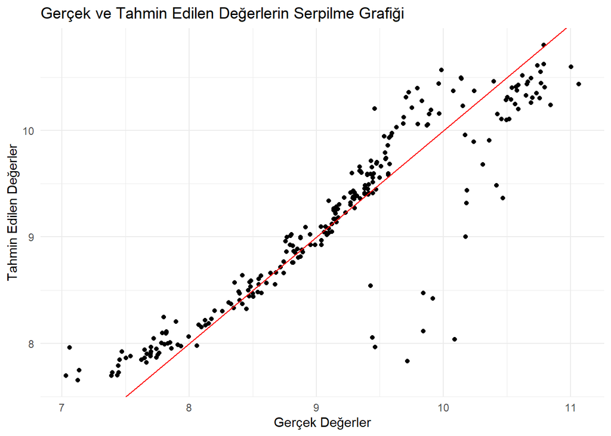

```r
# Serpilme grafiği çizme
library(ggplot2)
ggplot(results, aes(x = real, y = predicted)) +
  geom_point() +
  geom_abline(slope = 1, intercept = 0, color = "red") +
  labs(title = "Gerçek ve Tahmin Edilen Değerlerin Serpilme Grafiği",
       x = "Gerçek Değerler",
       y = "Tahmin Edilen Değerler") +
  theme_minimal()
```

```r
# R-kare değerini hesaplama
r_squared <- cor(results$real, results$predicted)^2
print(paste("Test Seti R-kare:", r_squared))
```

```
## [1] "Test Seti R-kare: 0.828000426768596"
```